# Lab 9 Assignment

Name: Chance Yan

Date: 4/3/25

1. State the Question/Hypothesis

What environmental factors/influences affect Martin abundances?

Null hypothesis: Martin abundance is random Hypothesis: Martin abundances should be impacted by factors such as elevation, snow penetration, snow depth, and trail type 2. Data exploration

```r
#loading libraries and appropriate data
library(AICcmodavg)
library(MuMIn)
```

```r
library(lattice)
library(corrplot)
library(car)
library(ggplot2)
library(HH)
library(GGally)
library(tidyverse)
#downloading data frame
counts <- read.csv("track.counts.csv",header=TRUE)
str(counts)
```

```
## 'data.frame':    112 obs. of  7 variables:
##  $ coy      : int  0 0 3 1 0 4 0 0 0 0 ...
##  $ fx       : int  0 0 3 0 0 0 0 0 0 0 ...
##  $ mart     : int  3 1 1 0 2 1 2 1 3 2 ...
##  $ depth    : num  16.4 22.2 59.8 61.8 14.2 55.8 69.8 7 15.8 45.8 ...
##  $ penetrat : num  12 19.6 14.8 9.6 14.8 13.8 11.8 5 13.4 32.8 ...
##  $ tt       : chr  "hike" "hike" "hike" "hike" ...
##  $ elevation: num  946 946 946 946 837 ...
```

```r
summary(counts)
```

```
##       coy               fx              mart           depth
##  Min.   : 0.000   Min.   : 0.000   Min.   : 0.00   Min.   :  4.00
##  1st Qu.: 0.000   1st Qu.: 0.000   1st Qu.: 0.00   1st Qu.: 16.70
##  Median : 0.000   Median : 1.000   Median : 1.00   Median : 38.70
##  Mean   : 1.509   Mean   : 1.929   Mean   : 1.58   Mean   : 48.04
##  3rd Qu.: 0.000   3rd Qu.: 3.250   3rd Qu.: 2.00   3rd Qu.: 72.30
##  Max.   :90.000   Max.   :12.000   Max.   :55.00   Max.   :114.00
##     penetrat          tt              elevation
##  Min.   : 3.60   Length:112         Min.   : 640.9
##  1st Qu.: 9.60   Class :character   1st Qu.: 733.2
##  Median :13.40   Mode  :character   Median : 824.9
##  Mean   :15.81                      Mean   : 819.0
##  3rd Qu.:18.65                      3rd Qu.: 901.2
##  Max.   :46.20                      Max.   :1033.6
```

```r
head(counts)
```

```
##   coy fx mart depth penetrat   tt elevation
## 1   0  0    3  16.4     12.0 hike  946.0328
## 2   0  0    1  22.2     19.6 hike  946.0328
## 3   3  3    1  59.8     14.8 hike  946.0328
## 4   1  0    0  61.8      9.6 hike  946.0328
## 5   0  0    2  14.2     14.8 hike  836.8361
## 6   4  0    1  55.8     13.8 hike  836.8361
```

```r
#translating variables to z score to make it easier to compare
counts$elevationz <- c(scale(counts$elevation))
counts$penetratz <- c(scale(counts$penetrat))
counts$depthz <- c(scale(counts$depth))
```

3. Describe the model

We’ll use either a poisson distribution or negative binomial distribution. Since it is count data we might use binomial distribution to account for excess. We’ll assume no collinearity for this model (which we will check).

Now that we have our data, we’ll look at the data to see if we can spot any patterns.

```r
backupCount <- counts
counts = subset(counts, counts$mart != 55)

(mean.mart <- mean(counts$mart))
```

```
## [1] 1.099099
```

```r
(var.mart <- var(counts$mart))
```

```
## [1] 1.508272
```

```r
(lam <- mean(counts$mart))
```

```
## [1] 1.099099
```

```r
(var.mart <- var(counts$mart))
```

```
## [1] 1.508272
```

```r
(exp <- dpois(0,lam))
```

```
## [1] 0.3331711
```

```r
(obs <- mean(counts$mart==0))
```

```
## [1] 0.4054054
```

```r
(thet <- lam^2 / (var.mart - lam))
```

```
## [1] 2.952344
```

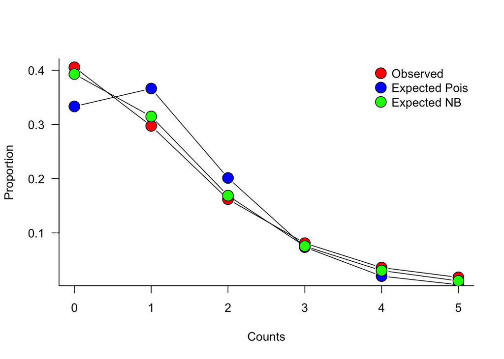

```r
freq <- c(table(factor(counts$mart,levels=0:5)))
observed <- with(counts, freq/sum(freq))
expected.pois <- dpois(0:5, lambda=mean.mart) #poisson random variables
expected.nb <- dnbinom(0:5, mu=mean.mart, size=thet) #negbin random variables
# Plot the expected vs. the observed counts
plot(x = 0:5, y = observed, pch=21, bg="red", cex=2, type="b",
xlab="Counts", ylab="Proportion", bty="l", las=1)
points(x = 0:5, y = expected.pois, pch=21, bg="blue", cex=2, type="b")
points(x = 0:5, y = expected.nb, pch=21, bg="green", cex=2, type="b")
legend("topright", c("Observed", "Expected Pois","Expected NB"), pch=21,
pt.cex=2, bty="n", pt.bg=c("red","blue","green"))
```

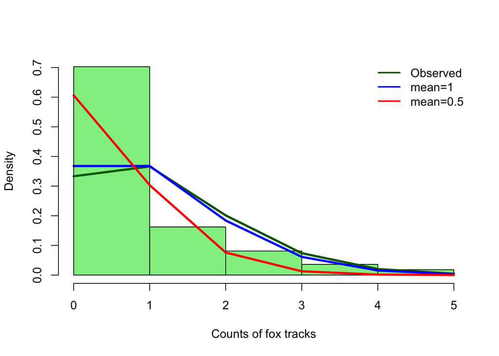

```r
hist(counts$mart,breaks=seq(0,5,1),right=TRUE,freq=FALSE,
col="lightgreen",main="", xlab="Counts of fox tracks")
obs.seq <- 0:5
emp.lam <- mean(counts$mart)
lines(obs.seq, dpois(obs.seq, emp.lam), lwd=3, col="darkgreen")
lines(obs.seq, dpois(obs.seq, 1), lwd=3, col="blue")
lines(obs.seq, dpois(obs.seq, 0.5), lwd=3, col="red")
legend("topright",c("Observed","mean=1","mean=0.5"), lwd=2,
col=c("darkgreen","blue","red"), bty="n")
```

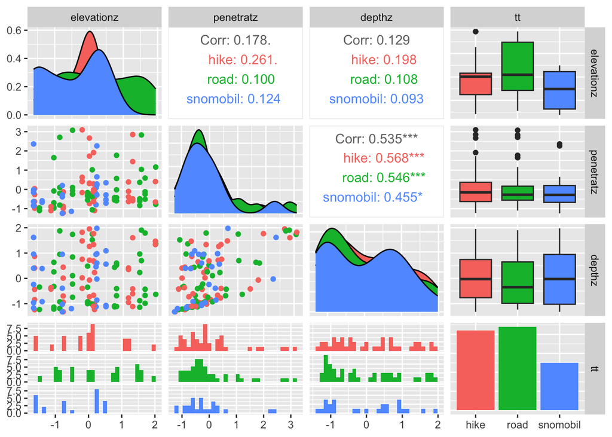

```r
#check if other explanatory variables were the effect
covs <- c("elevationz", "penetratz", "depthz", "tt")
ggpairs(counts[,covs],mapping = aes(color = tt))
```

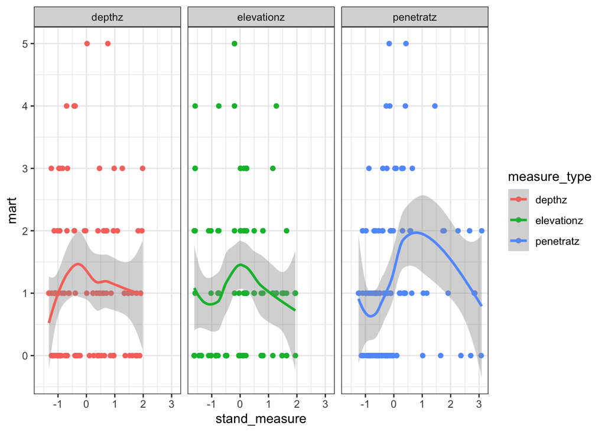

```r
#check for x^2
counts_l <- counts %>%
select(mart, elevationz, penetratz, depthz) %>%
pivot_longer(c(elevationz, penetratz, depthz), names_to = "measure_type",
values_to = "stand_measure")
ggplot(counts_l, aes(x = stand_measure, y = mart, colour = measure_type)) +
geom_point() +
geom_smooth() +
facet_wrap(~ measure_type) +
theme_bw()
```

```r
#collinearity screen
library(psych)
```

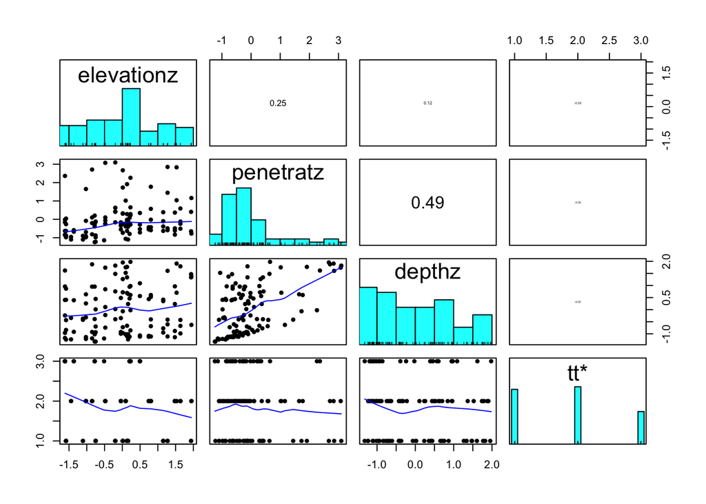

```r
pairs.panels(counts[,c("elevationz","penetratz","depthz","tt")],
scale=TRUE,density=FALSE,ellipses=FALSE, method="spearman")
```

```r
#VIF for collinearity
library(car)
vif(glm(mart ~ elevationz + penetratz + depthz + tt,
data=counts, family="poisson"))
```

```
## elevationz  penetratz     depthz     ttroad ttsnomobil
##   1.127389   1.427137   1.411196   1.262205   1.284293
```

Going forward I will remove the 55 observation as I believe it to not be true to the dataset. Perhaps there was a mart going back and forth creating more trails in the same area. I expect this due to it’s much larger number than the rest of the abundances.

Now that we understand that there isn’t collinearity and no exponential portion. Let’s try modeling the data. We’ll start with poisson and move to negative binomial.

```r
library(AER)
Mpois <- glm(mart ~ elevationz + depthz + penetratz + tt,
data=counts, family="poisson")

# model fit - the Pearson Chi-square test (p<0.05 = significant lack of fit)
1-pchisq(summary(Mpois)$deviance, summary(Mpois)$df.residual)
```

```
## [1] 0.3481094
```

```r
# dispersion parameter - dev/dof should ~1
(chat <- Mpois$deviance/Mpois$df.residual)
```

```
## [1] 1.048314
```

```r
# overdispersion - statistical test of H0: od=1
library(AER)
dispersiontest(Mpois)
```

```
##
##  Overdispersion test
##
## data:  Mpois
## z = -0.20485, p-value = 0.5812
## alternative hypothesis: true dispersion is greater than 1
## sample estimates:
## dispersion
##  0.9812136
```

```r
library(DHARMa)
```

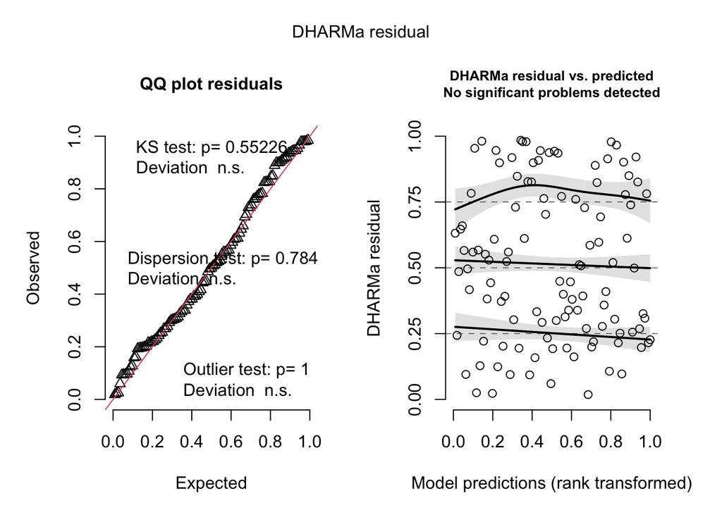

```r
Mpois.resids <- simulateResiduals(Mpois)
plot(Mpois.resids)
```

```r
#modelling to negative binomial
library(MASS)
Mnb <- glm.nb(mart ~ elevationz + depthz + penetratz + tt, data=counts)
summary(Mnb)
```

```
##
## Call:
## glm.nb(formula = mart ~ elevationz + depthz + penetratz + tt,
##     data = counts, init.theta = 8339.856288, link = log)
##
## Coefficients:
##             Estimate Std. Error z value Pr(>|z|)
## (Intercept)  0.62258    0.11365   5.478  4.3e-08 ***
## elevationz   0.04006    0.10071   0.398   0.6908
## depthz      -0.13102    0.11151  -1.175   0.2400
## penetratz    0.21779    0.10206   2.134   0.0329 *
## ttroad      -1.61658    0.26875  -6.015  1.8e-09 ***
## ttsnomobil  -0.59369    0.23513  -2.525   0.0116 *
## ---
## Signif. codes:  0 '***' 0.001 '**' 0.01 '*' 0.05 '.' 0.1 ' ' 1
##
## (Dispersion parameter for Negative Binomial(8339.856) family taken to be 1)
##
##     Null deviance: 162.71  on 110  degrees of freedom
## Residual deviance: 110.06  on 105  degrees of freedom
## AIC: 284.07
##
## Number of Fisher Scoring iterations: 1
##
##
##               Theta:  8340
##           Std. Err.:  136922
## Warning while fitting theta: iteration limit reached
##
##  2 x log-likelihood:  -270.072
```

```r
# model fit - the Pearson Chi-square test (p<0.05 = signoficant lack of fit)
1-pchisq(summary(Mnb)$deviance, summary(Mnb)$df.residual)
```

```
## [1] 0.3484437
```

```r
# dispersion parameter - dev/dof approximation should ~1
(chat <- Mnb$deviance/Mnb$df.residual)
```

```
## [1] 1.048186
```

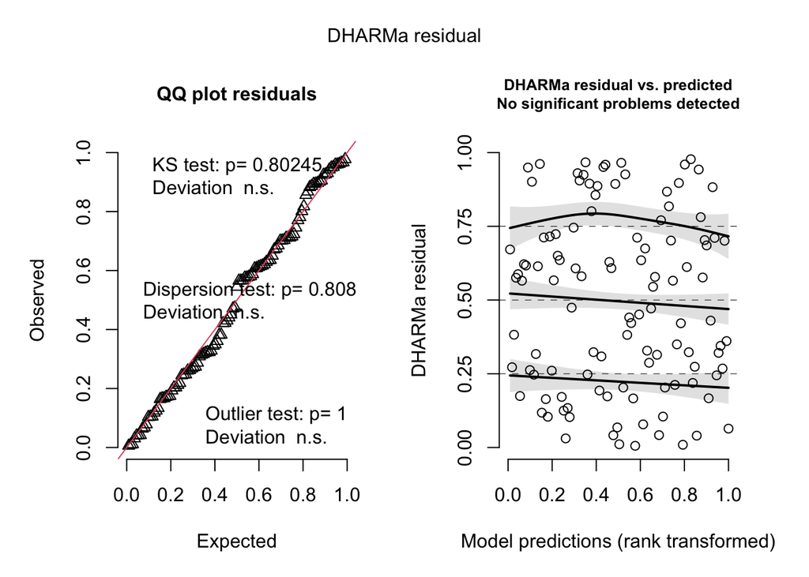

```r
Mnb.resids <- simulateResiduals(Mnb)
plot(Mnb.resids)
```

Ok totally not what I expected… Both models preform well. Looking at the graph on the right; however, for the poisson distribution it seems to be a little cleaner than for the count model. I guess it makes sense given that when I originally graphed the negative binomial and poisson expected values they both weren’t far off from the observed values. (I had thought though the negative binomial fit more, but math proved me wrong)

4. Fit the model

Let’s create the model and compare using AIC

```r
fitList <- list(
"m.full" = glm(mart ~ elevationz + depthz + penetratz + tt, data=counts, family="poisson"),
"m.edp" = glm(mart ~ elevationz + depthz + penetratz, data=counts, family="poisson"),
"m.edtt" = glm(mart ~ elevationz + depthz + tt, data=counts, family="poisson"),
"m.eptt" = glm(mart ~ elevationz + penetratz + tt, data=counts, family="poisson"),
"m.dptt" = glm(mart ~ depthz + penetratz + tt, data=counts, family="poisson"),
"m.ed" = glm(mart ~ elevationz + depthz, data=counts, family="poisson"),
"m.ep" = glm(mart ~ elevationz + penetratz, data=counts, family="poisson"),
"m.ett" = glm(mart ~ elevationz + tt, data=counts, family="poisson"),
"m.dp" = glm(mart ~ depthz + penetratz, data=counts, family="poisson"),
"m.dtt" = glm(mart ~ depthz + tt, data=counts, family="poisson"),
"m.ptt" = glm(mart ~ penetratz + tt, data=counts, family="poisson"),
"m.e" = glm(mart ~ elevationz, data=counts, family="poisson"),
"m.d" = glm(mart ~ depthz, data=counts, family="poisson"),
"m.p" = glm(mart ~ penetratz, data=counts, family="poisson"),
"m.tt" = glm(mart ~ tt, data=counts, family="poisson"),
"m.0" = glm(mart ~ 1, data=counts, family="poisson")
)
aictab(fitList)
```

```
##
## Model selection based on AICc:
##
##        K   AICc Delta_AICc AICcWt Cum.Wt      LL
## m.ptt  4 279.98       0.00   0.30   0.30 -135.80
## m.dptt 5 280.80       0.82   0.20   0.51 -135.11
## m.tt   3 281.24       1.26   0.16   0.67 -137.51
## m.eptt 5 282.04       2.06   0.11   0.78 -135.73
## m.ett  4 282.88       2.90   0.07   0.85 -137.25
## m.full 6 282.88       2.90   0.07   0.92 -135.04
## m.dtt  4 283.39       3.41   0.06   0.98 -137.50
## m.edtt 5 285.07       5.09   0.02   1.00 -137.25
## m.p    2 323.02      43.04   0.00   1.00 -159.45
## m.dp   3 324.53      44.56   0.00   1.00 -159.15
## m.0    1 324.76      44.78   0.00   1.00 -161.36
## m.ep   3 325.03      45.05   0.00   1.00 -159.40
## m.edp  4 326.59      46.62   0.00   1.00 -159.11
## m.d    2 326.63      46.65   0.00   1.00 -161.26
## m.e    2 326.83      46.86   0.00   1.00 -161.36
## m.ed   3 328.74      48.76   0.00   1.00 -161.26
```

The top two models are very close, but I’m more inclined to choose the m.ptt model as it has less variables. Moving on to testing if this model is a good fit.

5. Evaluate the output

```r
b.mod <- glm(mart ~ penetratz + tt, data=counts, family="poisson")
summary(b.mod)
```

```
##
## Call:
## glm(formula = mart ~ penetratz + tt, family = "poisson", data = counts)
##
## Coefficients:
##             Estimate Std. Error z value Pr(>|z|)
## (Intercept)  0.62214    0.11349   5.482 4.21e-08 ***
## penetratz    0.15377    0.08029   1.915  0.05549 .
## ttroad      -1.59139    0.26705  -5.959 2.54e-09 ***
## ttsnomobil  -0.61142    0.22999  -2.658  0.00785 **
## ---
## Signif. codes:  0 '***' 0.001 '**' 0.01 '*' 0.05 '.' 0.1 ' ' 1
##
## (Dispersion parameter for poisson family taken to be 1)
##
##     Null deviance: 162.73  on 110  degrees of freedom
## Residual deviance: 111.60  on 107  degrees of freedom
## AIC: 279.6
##
## Number of Fisher Scoring iterations: 5
```

```r
library(AER)

# model fit - the Pearson Chi-square test (p<0.05 = significant lack of fit)
1-pchisq(summary(b.mod)$deviance, summary(b.mod)$df.residual)
```

```
## [1] 0.3610698
```

```r
# dispersion parameter - dev/dof should ~1
(chat <- b.mod$deviance/b.mod$df.residual)
```

```
## [1] 1.043007
```

```r
# overdispersion - statistical test of H0: od=1
library(AER)
dispersiontest(b.mod)
```

```
##
##  Overdispersion test
##
## data:  b.mod
## z = -0.22088, p-value = 0.5874
## alternative hypothesis: true dispersion is greater than 1
## sample estimates:
## dispersion
##   0.980028
```

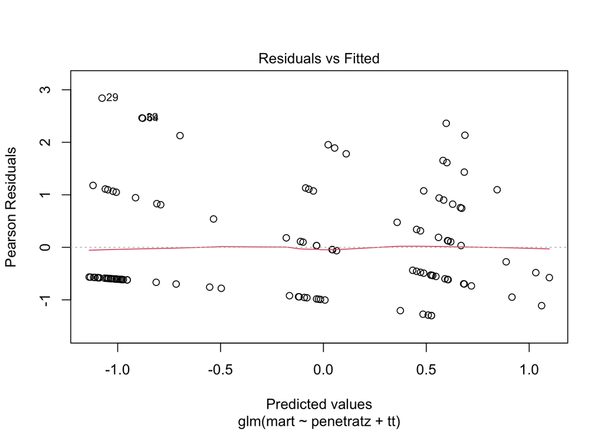

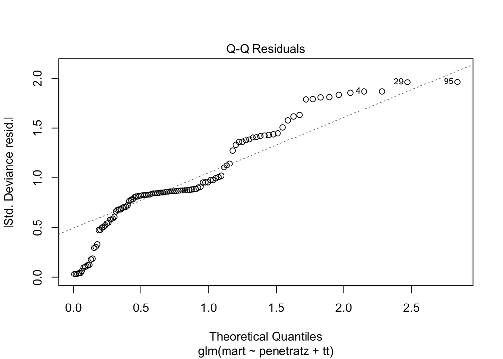

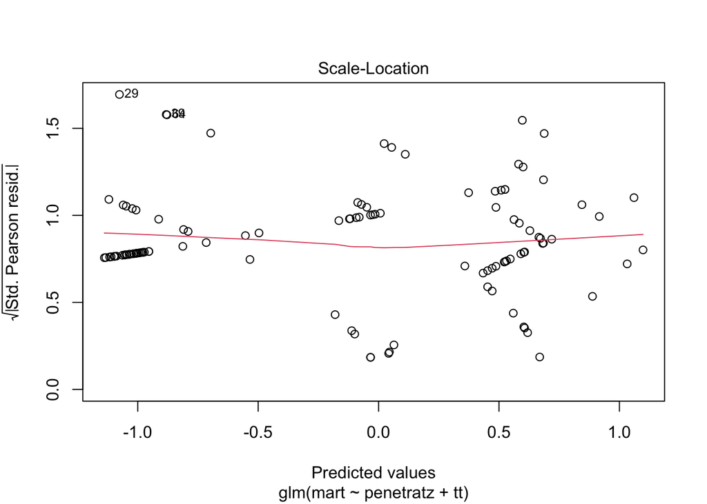

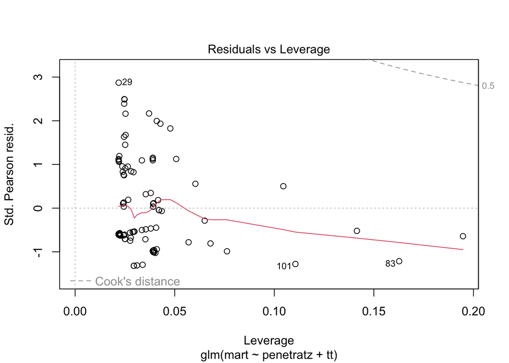

```r
library(DHARMa)
b.mod.resids <- simulateResiduals(b.mod)
plot(b.mod)
```

The model is alright looking… Most points are random and nothing goes above the residuals vs leverage graph. The QQ plot is a bit shaky, but we’ll live.

Time to visualize our results

6. Interpret the Results

```r
df.predict <- expand.grid(
penetratz = seq(min(counts$penetratz), max(counts$penetratz), length=100),
tt = unique(counts$tt)
)
# predict on the response scale
df.pred <- cbind(df.predict, predict(b.mod, newdata = df.predict,
type = "response", se = TRUE))
head(df.pred)
```

```
##   penetratz   tt      fit    se.fit residual.scale
## 1 -1.243404 hike 1.538706 0.2516456              1
## 2 -1.199581 hike 1.549110 0.2493966              1
## 3 -1.155757 hike 1.559584 0.2471635              1
## 4 -1.111933 hike 1.570129 0.2449500              1
## 5 -1.068110 hike 1.580745 0.2427596              1
## 6 -1.024286 hike 1.591433 0.2405965              1
```

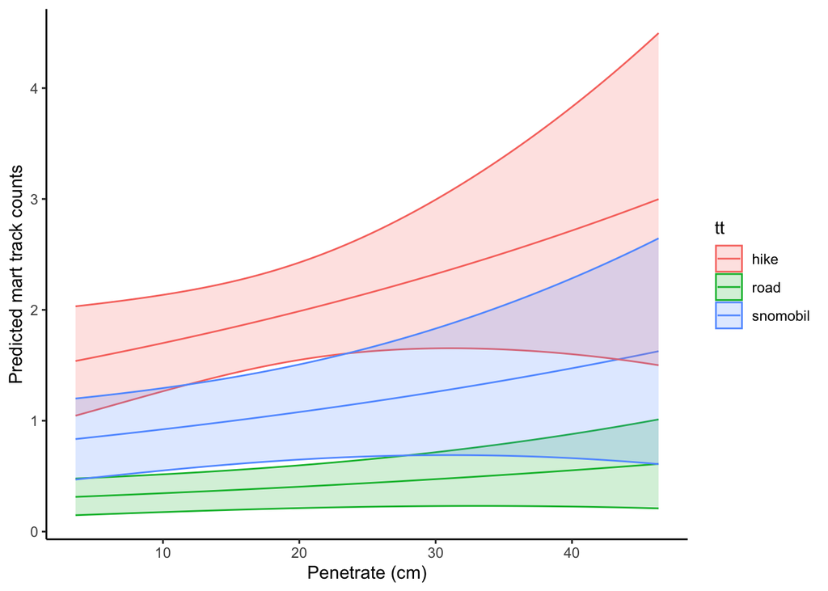

```r
remove(df.predict)
df.pred$ci.lo <- df.pred$fit - 1.96*df.pred$se.fit
df.pred$ci.hi <- df.pred$fit + 1.96*df.pred$se.fit
# unscale our explanatory variables
df.pred$penetrat <- (df.pred$penetratz*sd(counts$penetrat,na.rm = TRUE)) +
mean(counts$penetrat,na.rm = TRUE)
# plot!
ggplot(df.pred, aes(x = penetrat, y = fit, colour = tt, fill = tt)) +
geom_line() +
geom_ribbon(data = df.pred, aes(ymin = ci.lo, ymax = ci.hi),
alpha = 0.2) +
xlab("Penetrate (cm)") + ylab("Predicted mart track counts") +
theme_classic()
```